# Analysis Summary

In the below analysis,

- I have used Titanic Dataset.
- I am testing how survivability (dependent variable) depends on Age, Gender, Pclass and Embarked port (Independent Variables).
- Created bar graphs and $\chi^2$ tests to confirm if the dependency exists.
- 1D explorations of some independent variables to see how they are distributed.
- Scatter plot to see how Fare and Age are distributed.
- Data wrangling was not done as the dataset is clean and functioning.

```python
### Reading Titanic csv and putting in a dataframe
import matplotlib.pyplot as plt
import pandas as pd
import numpy as np
import seaborn as sns
import scipy

titanic_df=pd.read_csv('titanic-data.csv')
```

```python
### Function to calculate chi square statistics for multiple independent variables
def calculate_chi_square_stats(independent_variable, alpha, degrees_of_freedom ):
    #Overall_rate
    survived= titanic_df['Survived'].mean()
    #Observed
    observed=titanic_df.groupby([independent_variable]).sum()['Survived']
    #expected
    expected=titanic_df.groupby([independent_variable]).count()['Survived']*survived
    #Chi square statistics
    chiStats= scipy.stats.chisquare(observed,expected,ddof=0)
    return chiStats
```

```python
#Function to plot bar graph
%pylab inline

def bar_graph_creation(groupby_var1, groupby_var2, agg_var, agg_type):
    survivability_count_per_var=titanic_df.groupby([groupby_var1,groupby_var2]).agg({agg_var:agg_type})
    survivability_percent_per_var=survivability_count_per_var.groupby(level=0).apply(lambda x:100 * x / float(x.sum()))
    survivability_reset_index=survivability_percent_per_var.reset_index()
    plt.ylim(0,100)
    return sns.barplot(x=groupby_var1, y=agg_var, hue='Survived',data=survivability_reset_index)
```

# Survivability Vs Sex

We first want to see if sex has influence on survivability. Here, sex is an independent variable and survivability is a dependent variable. To do this:

- We will plot a graph between sex and survivability
- We will also run a null hypothesis to check the dependence of survivability on sex

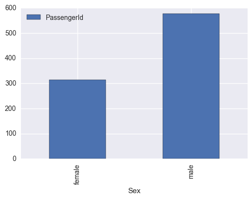

```python
#1D exploration of Sex
Count_People_Per_Sex=titanic_df.groupby('Sex').agg({'PassengerId' : 'count'})
Count_People_Per_Sex.plot(kind='bar')
```

As can be seen with the above exploration of column Sex, there are more males in the dataset than females

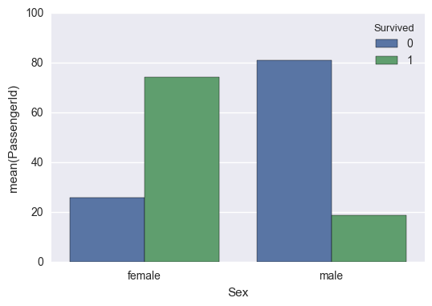

```python
### Reading the Survived data from titanic dataframe to create a bar graph based upon survivability and Sex
# 2D exploration of Sex and Survivability through bar plot
bar_graph_creation('Sex','Survived','PassengerId','count')
```

Although there are more males than females, the percentage of female survived is greater than male survived.From the plot it looks like that the survivability depends on Sex. We will use $\chi^2$ test to confirm our hypothesis

### Hypothesis Testing

**Null Hypothesis**: Survivability is independent of the sex.

```python
chistat_for_Sex=calculate_chi_square_stats ('Sex',.05,1)
print chistat_for_Sex
```

```
Power_divergenceResult(statistic=162.08166685161615, pvalue=3.970516389658672e-37)
```

### Hypothesis testing result

The p-value is 3.970516389658672e-37 which is significant at $\alpha =0.05$ level. This means that we reject the null i.e Survivability is dependent on Sex

# Survivability Vs Passenger Class

We first want to see if Pclass has influence on survivability. Here, Pclass is an independent variable and survivability is a dependent variable. To do this:

- We will plot a graph between Pclass and survivability
- We will also run a null hypothesis to check the dependence of survivability on Pclass

```
Pclass
1    216
2    184
3    491
Name: Count, dtype: int64
```

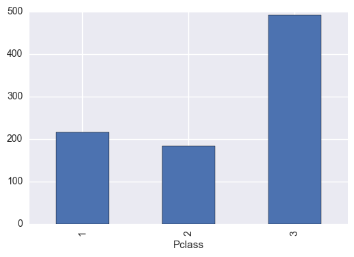

```python
###1D exploration of Pclass
titanic_df['Count'] = 1
countClass = titanic_df.groupby(['Pclass']).count()['Count']
countClass.plot(kind='bar')
print countClass
```

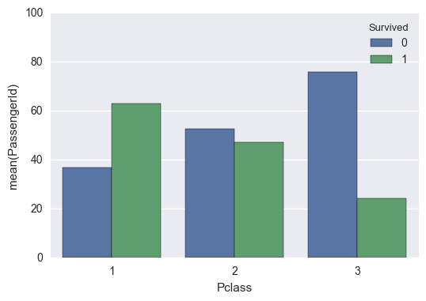

```python
# Reading the Survived data from titanic dataframe to create a bar graph based upon survivability and Passenger Class
# 2D exploration of Survived and Pclass
bar_graph_creation('Pclass','Survived','PassengerId','count')
```

The maximum number of people were in third class but the survival rate is the lowest in third class. From the plot it looks like that the survivability depends on pclass. We will use $\chi^2$ test to confirm our hypothesis

### Hypothesis Testing

**Null Hypothesis**: Survivability is independent of the pclass.

```python
chistat_for_Pclass=calculate_chi_square_stats('Pclass',.05,2)
print chistat_for_Pclass
```

```
Power_divergenceResult(statistic=63.396245597723173, pvalue=1.7126955990497913e-14)
```

### Hypothesis testing result

The p-Value is $1.7126955990497913e-14$ which is significant at $\alpha =0.05$ level. This means that we reject null i.e. Survivability depends on pclass.

# Survivability Vs Embarked

We first want to see if embarked has influence on survivability. Here, embarked is an independent variable and survivability is a dependent variable. To do this:

- We will plot a graph between embarked and survivability
- We will also run a null hypothesis to check the dependence of survivability on embarked

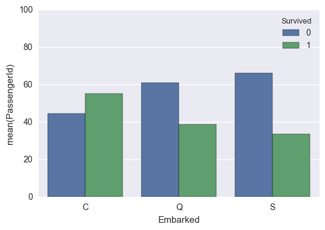

```python
# Reading the Survived data from titanic dataframe to create a bar graph based upon survivability and Embarked port
#2D exploration of Embarked and Survivability
bar_graph_creation('Embarked','Survived','PassengerId','count')
```

From the plot it looks like that the survivability depends on embarked. We will use $\chi^2$ test to confirm our hypothesis

### Hypothesis Testing

**Null Hypothesis**: Survivability is independent of the embarked.

```python
chistat_for_Pclass=calculate_chi_square_stats('Embarked',.05,2)
print chistat_for_Pclass
```

```
Power_divergenceResult(statistic=16.303690509211101, pvalue=0.00028820306064068123)
```

### Hypothesis testing result

The p-Value is $0.00028820306064068123$ which is significant at $\alpha =0.05$ level. This means that we reject null i.e. Survivability depends on embarked.

# Survivability Vs Age

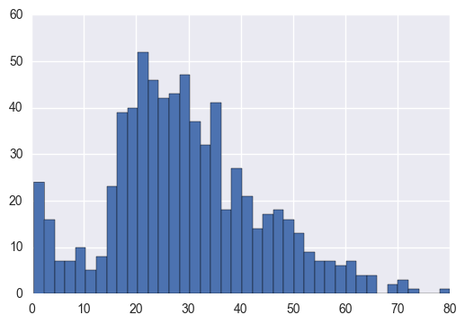

```python
#Histogram showing distribution of Age
#1D exploration of Age
titanic_df['Age'].hist(bins=40)
```

From the above plot it looks like that the distribution is concentrated between the age group 18-36 years

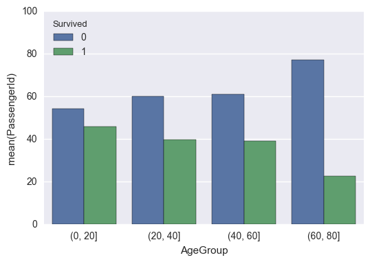

```python
#Reading the data to check relationship between Survivability and Age
#2D exploration of Survivability and Age
bins=[0,20,40,60,80]
titanic_df['AgeGroup'] = pd.cut(titanic_df['Age'], bins)
bar_graph_creation('AgeGroup','Survived','PassengerId','count')
```

From the plot it looks like that people in the age group 0-20 survived the most.

```python
#Mean Survived age for the whole dataset
#1D exploration of Age
titanic_df_survived=titanic_df[titanic_df.Survived==1]
titanic_df_survived['Age'].mean()
```

```
28.343689655172415
```

## Age vs Fare

We would like to see how the age and fare are related through the scatterplot below. Is Fare dependent on Age?

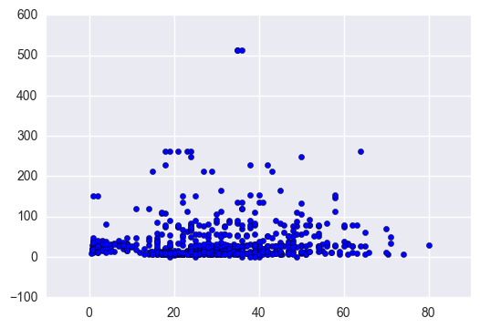

```python
y=titanic_df['Fare']
x=titanic_df['Age']
plt.scatter(x,y)
```

Its not a solid pattern but generally it can be said that children paid less fare than adults. Hypothesis testing can be done to confirm if fare is dependent on age